# Data 1 Tutorial

# 1 Overview

This is the tutorial for Data Module 1. This document will present the information necessary to complete the first data assignment in ENVS337.

# 2 Project setup

- Make an ENVS337 project
- Set “save work space image” to never
- Change pane layout to match in class example
- Make a `data/` and `plots/` subfolder

# 3 Setup and Data

## 3.1 Download and attach library

```r
# libraries

# run this just once on each machine
# install.packages("tidyverse")

# load this EVERY time you start R
library(tidyverse)
```

## 3.2 Data

- Download data from D2L and put it in your `data/` folder.
- Load the data into your RStudio session

```r
# data

bp <- read_csv("data/bonita_peak.csv")
```

### 3.2.1 View data

```r
bp
```

```
# A tibble: 486 × 13
   stream  site  site_id taxon total_count count phylum class order family genus
   <chr>   <chr> <chr>   <chr>       <dbl> <dbl> <chr>  <chr> <chr> <chr>  <chr>
 1 mill_cr abv_… MILaM   Amel…       12640    16 Arthr… Inse… Ephe… Amele… Amel…
 2 bear_cr abv_… BEaM    Amel…        2832     5 Arthr… Inse… Ephe… Amele… Amel…
 3 sf_ani… abv_… SFAaAV  Amel…        5384    16 Arthr… Inse… Ephe… Amele… Amel…
 4 sf_ani… abv_… SFAaEU  Amel…         668     3 Arthr… Inse… Ephe… Amele… Amel…
 5 eureka… abv_… EUaSFA  Amel…         622     1 Arthr… Inse… Ephe… Amele… Amel…
 6 sf_ani… abv_… SFAaA   Amel…        1437     5 Arthr… Inse… Ephe… Amele… Amel…
 7 hermos… abv_… HERaD   Amel…        1768     6 Arthr… Inse… Ephe… Amele… Amel…
 8 wf_ani… abv_… WFAaPL  Amph…          40     2 Arthr… Inse… Plec… Nemou… Amph…
 9 hermos… abv_… HERaD   Anto…        1768    35 Arthr… Inse… Dipt… Tipul… Anto…
10 minera… abv_… MaMIL   Arct…         397     5 Arthr… Inse… Tric… Hydro… <NA>
# ℹ 476 more rows
# ℹ 2 more variables: habit <chr>, FFG <chr>
```

## 3.3 Data background

- Mountain Studies Institute (MSI) in Durango/Silverton conducted this study
- Sampled streams throughout the Bonita Peak Mining District located in San Juan County, CO
  - [USEPA website](https://www.epa.gov/bpmd)
  - [CDPHE website](https://cdphe.colorado.gov/hm/bonita-peak-mining-district)
- Samples included benthic macroinvertebrates as well as water quality data
- We will look at the macroinvertebrate data here
- The water quality data will be incorporated in data module 2

## 3.4 Data structure

- Each row is the information for one taxon
- Includes the `stream` name and specific `site` information as well as a unique `site_id`
- There are columns for the complete taxonomic information for each taxon: `phylum`, `class`, `order`, `family`, and `genus`.
  - When information is unknown it appears as an `NA` which means “Not Available”
- The `taxon` column includes the lowest taxonomic information available for that group, typically a Genus name.
- When the species information is known, the Genus and specific epithet are separated with an underscore
  - i.e., *Drunella doddsii* appears as” `Drunella_doddssii`
- There is also information on the `habit` ’s and `FFG` ’s for each taxon.

### 3.4.1 Filter data to two example sites

- We will be just looking at two sites around Burrows Creek

**Homework Note**

- You will be looking at two different sites in your Homework
- Be sure to change the code in your homework script appropriately.

```r
burrows <- bp |>
  filter(site_id =="BUaNFA" |
           site_id =="NFAaBU")
burrows
```

```
# A tibble: 45 × 13
   stream  site  site_id taxon total_count count phylum class order family genus
   <chr>   <chr> <chr>   <chr>       <dbl> <dbl> <chr>  <chr> <chr> <chr>  <chr>
 1 nf_ani… abv_… NFAaBU  Arct…        1419    48 Arthr… Inse… Tric… Hydro… <NA>
 2 nf_ani… abv_… NFAaBU  Bril…        1419     5 Arthr… Inse… Dipt… Chiro… Bril…
 3 burrow… abv_… BUaNFA  Capn…        1163     5 Arthr… Inse… Plec… Capni… <NA>
 4 nf_ani… abv_… NFAaBU  Chae…        1419     5 Arthr… Inse… Dipt… Chiro… Chae…
 5 burrow… abv_… BUaNFA  Chae…        1163    18 Arthr… Inse… Dipt… Chiro… Chae…
 6 nf_ani… abv_… NFAaBU  Ciny…        1419   123 Arthr… Inse… Ephe… Hepta… Ciny…
 7 nf_ani… abv_… NFAaBU  Clin…        1419     3 Arthr… Inse… Dipt… Empid… Clin…
 8 burrow… abv_… BUaNFA  Clin…        1163    85 Arthr… Inse… Dipt… Empid… Clin…
 9 nf_ani… abv_… NFAaBU  Cric…        1419    40 Arthr… Inse… Dipt… Chiro… Cric…
10 nf_ani… abv_… NFAaBU  Diam…        1419    24 Arthr… Inse… Dipt… Chiro… Diam…
# ℹ 35 more rows
# ℹ 2 more variables: habit <chr>, FFG <chr>
```

# 4 Calculate Metrics

- We will calculate a number of different metrics in class.
- Some of these will be exactly the same on the homework assignment
- Some of the homework problems will require you to modify the code to get the right answer.

## 4.1 Total abundance

```r
burrows |>
  group_by(stream) |>
  distinct(total_count)
```

```
# A tibble: 2 × 2
# Groups:   stream [2]
  stream    total_count
  <chr>           <dbl>
1 nf_animas        1419
2 burrow_cr        1163
```

- Note that this result appears in the console and then disappears
- Below, we will save our results in a new data object for later use.

## 4.2 Richness

```r
total_rich <- burrows |>
  distinct(stream, taxon) |>
  group_by(stream) |>
  summarise(total_rich = n())
total_rich
```

```
# A tibble: 2 × 2
  stream    total_rich
  <chr>          <int>
1 burrow_cr         12
2 nf_animas         33
```

## 4.3 EPT Richness

```r
ept_rich <- burrows |>
  filter(order == "Ephemeroptera" |
           order == "Plecoptera" |
           order == "Trichoptera") |>
  distinct(stream, taxon) |>
  group_by(stream) |>
  summarise(EPT_rich = n())
ept_rich
```

```
# A tibble: 2 × 2
  stream    EPT_rich
  <chr>        <int>
1 burrow_cr        3
2 nf_animas       16
```

**Homework Note**

- For your HW, you will also calculate just the T richness
- To do this, you will modify your `filter()` command to the following:

`filter(order == "Trichoptera") |>`

## 4.4 Heptageniidae Richness

- Modify above code to filter based on the `family` column instead of the `order` column

```r
hept_rich <- burrows |>
  filter(family == "Heptageniidae") |>
  distinct(stream, taxon) |>
  group_by(stream) |>
  summarise(hept_rich = n())
hept_rich
```

```
# A tibble: 1 × 2
  stream    hept_rich
  <chr>         <int>
1 nf_animas         2
```

- Note that there are no Heptageniidae in Burrow creek so no line is returned.

# 5 % EPT individuals

```r
ept_per_n <- burrows |>
  filter(order == "Ephemeroptera" |
           order == "Plecoptera" |
           order == "Trichoptera") |>
  group_by(stream, total_count) |>
  summarize(ept_n = sum(count)) |>
  mutate(ept_percent_ind = ept_n / total_count)
ept_per_n
```

```
# A tibble: 2 × 4
# Groups:   stream [2]
  stream    total_count ept_n ept_percent_ind
  <chr>           <dbl> <dbl>           <dbl>
1 burrow_cr        1163    59          0.0507
2 nf_animas        1419  1218          0.858
```

**Homework Note**

- For your HW, you will also calculate the percent of individuals in the Chironomidae family
- You will need to combine code from both the Heptageniidae and %EPT individuals examples above.

## 5.1 Scraper FFG

- We will look at the scraper richness next.
- But first, here is code to show you all the unique values in a column

```r
burrows |>
  distinct(FFG)
```

```
# A tibble: 6 × 1
  FFG
  <chr>
1 filterer
2 collector
3 shredder
4 scraper
5 predator
6 <NA>
```

**Homework Note**

- Check the exact spelling of the FFG you want
- The Homework will ask you to look at the richness of the predator FFG

```r
scraper <- burrows |>
  filter(FFG == "scraper") |>
  distinct(stream, taxon) |>
  group_by(stream) |>
  summarise(hept_rich = n())
scraper
```

```
# A tibble: 1 × 2
  stream    hept_rich
  <chr>         <int>
1 nf_animas         5
```

- Note that once again there are no scrapers in Burrow creek, so there is no line in the result.

## 5.2 Shannon’s Diversity Index $H^\prime$

$$H^\prime = - \Sigma \, p_i \, \ln(p_i)$$

Where $p_i$ is the proportion of taxon $i$

```r
shannon <- burrows |>
  select(stream, taxon, count, total_count) |>
  mutate(pi = count / total_count,
         ln_pi = log(pi),
         pi_ln_pi = pi*ln_pi) |>
  group_by(stream) |>
  summarize(H = -sum(pi_ln_pi))
```

# 6 Plot Results

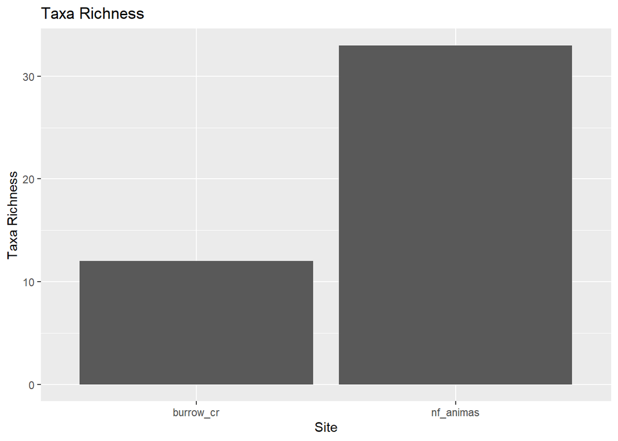

```r
 total_rich|>
  ggplot(aes(x = stream,
             y = total_rich)) +
  geom_col() +
  labs(x = "Site",
       y = "Taxa Richness",
       title = "Taxa Richness")
```

- You can also save this plot as a .png file in your R project

```r
ggsave("plots/total_richness.png",
       units = "in",
       height = 4,
       width = 4)
```

- Change the `height` and `width` columns as needed to get the right size
- You will be pasting plots into your homework document.
- Make sure they are the right size
- Go back to your script and change the sizes if needed.

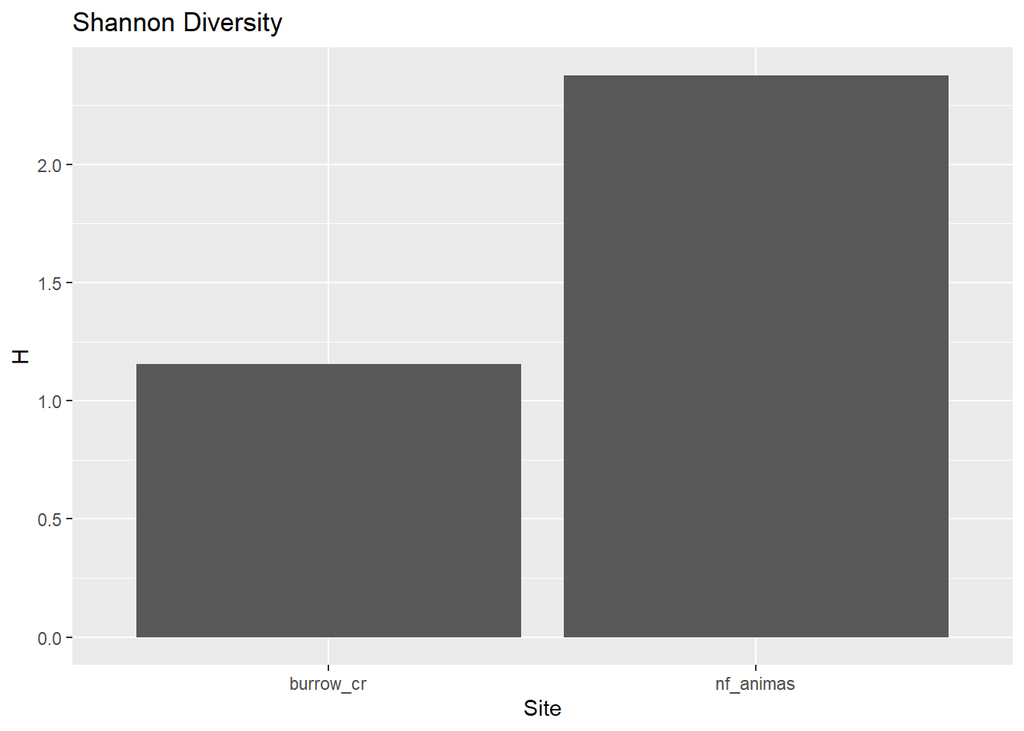

```r
shannon |>
  ggplot(aes(x = stream,
             y = H)) +
  geom_col() +
  labs(x = "Site",
       y = "H",
       title = "Shannon Diversity")
```

**Homework Note**

- The homework will ask you to make 4 plots
- Be sure to start with the object that has the result you want
  - i.e.,`tot_rich`, `shannon`, etc.
- In `aes()`, x will always be `x = stream`
- You will need to change the y-axis to whatever you named the column in your object
  - i.e., `y = total_rich`, `H`, etc.
- Change the title and y label in the `labs()` argument to match your results.

# 7 Conclusion

- This concludes the tutorial
- You should now be able to calculate all the metrics in the first data assignment